# Homework6_PalashiSinghal_06/11/22

*4. (2 pt) Conduct a post-hoc test to determine which is/are the borough(s) with the highest price. Which are the borough(s) with the lowest price?*

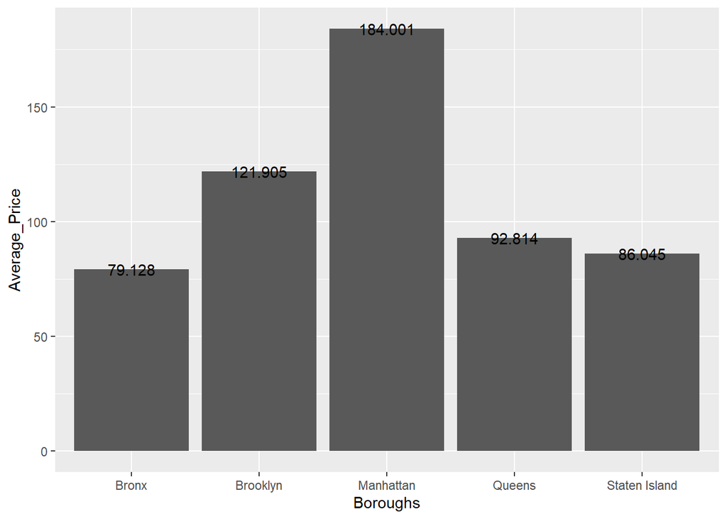

```r
question2p2
```

```r
pairwise.t.test(q3$price, q3$Neigbourhoods, p.adjust = "bonf")
```

```
##
##  Pairwise comparisons using t tests with pooled SD
##
## data:  q3$price and q3$Neigbourhoods
##
##               Bronx   Brooklyn Manhattan Queens
## Brooklyn      1.8e-13 -        -         -
## Manhattan     < 2e-16 < 2e-16  -         -
## Queens        0.2079  < 2e-16  < 2e-16   -
## Staten Island 1.0000  0.0005   < 2e-16   1.0000
##
## P value adjustment method: bonferroni
```

Manhattan has the highest price and a significant difference in price from all other boroughs. We can see that Manhattan has a significantly different price from other boroughs as well as the p-value is less than 0.005.

*5. (1 pt) Examine the room types. What is the frequency of each rental type in each borough? Prepare a graph illustrating it.*

```r
library(readxl)
airbnb_room_type <- read_excel("airbnb_room_type.xlsx")
View(airbnb_room_type)

neighbourhoods <- airbnb_price %>% separate("nbhood_full", into = c("boroughs", NA ), sep = ",")
```

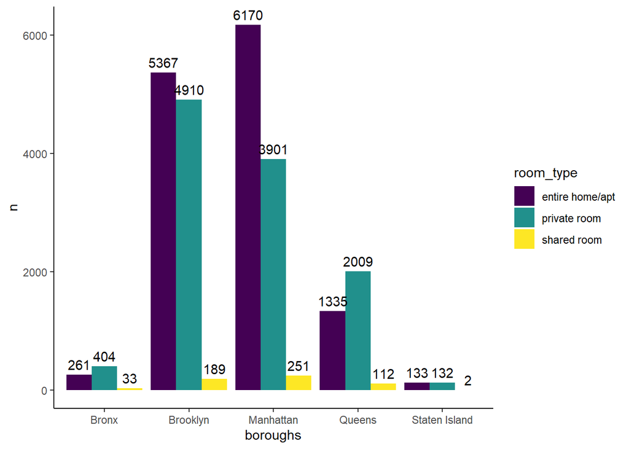

```r
joineddata <- inner_join(airbnb_room_type ,neighbourhoods, by = "listing_id")
q5data <- joineddata  %>% mutate(room_type = tolower(room_type))
q5data %>%
  group_by(boroughs, room_type) %>%
  summarize(n = n()) %>%
  ggplot(aes(x = boroughs, y = n, fill = room_type)) +
  geom_col(position = "dodge") +
  geom_text(aes(label = n), position = position_dodge(0.9), vjust = -0.5) +
  scale_fill_viridis_d() +
  theme_classic()
```

This graph illustrates the types of room types in each borough, as well the number of each type of room types in each borough.

*6. (2 pt) Do boroughs differ in what room types are the most common? Formally test it.*

For this question we conduct a chi-square test as there are categorical variables that we need to test. Chi-square null hypothesis : There is no relation between boroughs and room types.

```r
neighbourhoods <- airbnb_price %>% separate("nbhood_full", into = c("boroughs", NA ), sep = ",")
joineddata<- inner_join(airbnb_room_type ,neighbourhoods, by = "listing_id")
q6 <- joineddata %>% mutate(room_type = tolower(room_type)) %>% group_by( boroughs, room_type) %>% count() %>% group_by(boroughs)%>% mutate(percentcommon = n/sum(n)*100 ) %>% group_by(boroughs) %>% filter (percentcommon == max (percentcommon))
q6
```

| boroughs | room_type | n | percentcommon |
| --- | --- | --- | --- |
| Bronx | private room | 404 | 57.87966 |
| Brooklyn | entire home/apt | 5367 | 51.28034 |
| Manhattan | entire home/apt | 6170 | 59.77524 |
| Queens | private room | 2009 | 58.13079 |
| Staten Island | entire home/apt | 133 | 49.81273 |

```r
chisq_test(x = q5data, room_type ~ boroughs)
```

| statistic | chisq_df | p_value |
| --- | --- | --- |
| 595.5871 | 8 | 2.079168e-123 |

The p-value less than 0.05, that means that the room-types in each borough are significantly different. This also means that the most common room types in each borough differed significantly from each other.

*7. (1 pt) What additional information might you need to present to the investor to convince them? Prepare a list of variables that you need to collect and indicate a potential source of information about those variables (e.g. surveys, tax records etc)*

Additional information that we need to present to the investor :

1. Job market
2. Population Growth
3. Demand for properties in that specific locations
4. Growth in the rental prices over the next projected years
5. Presenting neighbourhood rating for the investors to know likelihood of the place
6. External costs including : maintainence and operating expenses
7. Taxes on property in the count

[output not shown]